# xwMOOC 모형 - `tidymodels`

## 3.3 Hyper Parameter 반영 최적모형

`workflow()` 를 정의하기에 앞서 모형 명세작업과 Hyper Parameter 준비작업을 하고 나서 작업흐름을 완성한다.

### 3.3.1 모형 명세

예측모형을 `lightgbm_spec` 명세하여 실제 훈련에 사용된 엔진도 함께 명세한다.

```r
lightgbm_spec <- boost_tree(
        mode = "classification",
        trees = 1000,
        min_n = tune(),
        tree_depth = tune()
        # loss_reduction = tune(),
        # learn_rate = tune()
    ) %>%
    set_engine("lightgbm", objective = "binary:binary_logloss", verbose = -1)
```

### 3.3.2 Hyper Parameter 탐색공간정의

Hyper Parameter 탐색공간을 정의한다. 먼저 탐색할 Hyper Parameter를 정의하고 나서, `grid_max_entropy()` 크기를 `size = 30`으로 특정하여 빠른 시간내 탐색이 될 수 있도록 한다.

```r
lightgbm_params <- dials::parameters(
        min_n(),
        tree_depth()
    )

lightgbm_grid <- dials::grid_max_entropy(
        lightgbm_params,
        size = 30)

lightgbm_grid
```

```
# A tibble: 30 x 2
   min_n tree_depth
   <int>      <int>
 1     6         13
 2     3         11
 3    10          7
 4    30          6
 5    29          2
 6    15          8
 7    19         13
 8    36          9
 9    13         12
10    21          1
# … with 20 more rows
```

### 3.3.3 `workflow` 흐름 작성

`workflow` 작업흐름을 생성하고 나서 명세된 모형, 레시피 feature engineering을 순차적으로 적어둔다.

```r
lightgbm_wf <- workflows::workflow() %>%
  # add_formula(sex ~ .) %>%
  add_recipe(penguin_rec) %>%
  add_model(lightgbm_spec)
```

### 3.3.4 Hyper Parameter 탐색실행[^4]

```r
library(doParallel)
all_cores <- parallel::detectCores(logical = FALSE)
registerDoParallel(cores = all_cores)

tictoc::tic()

lightgbm_tuned <- tune::tune_grid(
    object = lightgbm_wf,
    resamples = penguin_cv,
    grid = lightgbm_grid,
    metrics = yardstick::metric_set(roc_auc, accuracy),
    control = tune::control_grid(verbose = TRUE)
)

tictoc::toc()
```

```
102.541 sec elapsed
```

### 3.3.5 탐색 결과 살펴보기

`roc_auc` 기준으로 가장 성능좋은 Hyper Paramter 조합을 살펴보자.

```r
lightgbm_tuned %>%
  tune::show_best(metric = "roc_auc")
```

```
# A tibble: 5 x 8
  min_n tree_depth .metric .estimator  mean     n std_err .config
  <int>      <int> <chr>   <chr>      <dbl> <int>   <dbl> <chr>
1    21          1 roc_auc binary     0.934    10  0.0214 Model10
2    11          1 roc_auc binary     0.933    10  0.0221 Model19
3     4          1 roc_auc binary     0.931    10  0.0221 Model20
4    40          1 roc_auc binary     0.926    10  0.0223 Model16
5    25          2 roc_auc binary     0.916    10  0.0232 Model24
```

시각화를 통해 Hyper Paramter 탐색결과를 파악하자.

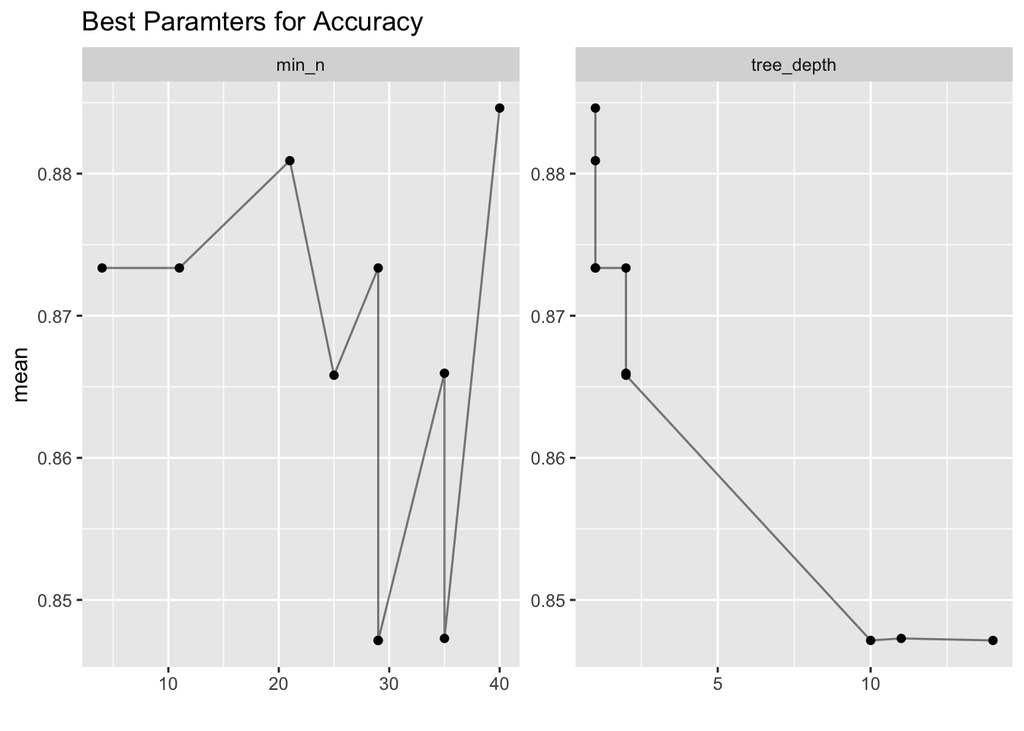

```r
lightgbm_tuned %>%
  tune::show_best(metric = "accuracy", n = 10) %>%
  tidyr::pivot_longer(min_n:tree_depth, names_to="variable", values_to="value" ) %>%
  ggplot(aes(value, mean)) +
  geom_line(alpha=1/2)+
  geom_point()+
  facet_wrap(~variable,scales = "free")+
  labs(x="", title = "Best Paramters for Accuracy")
```

### 3.3.6 최종모형 선정 및 마무리

```r
lightgbm_best_params <- lightgbm_tuned %>%
    tune::select_best("accuracy")

# lightgbm_best_params

lightgbm_model_final <- lightgbm_spec %>%
  finalize_model(lightgbm_best_params)

lightgbm_model_final
```

```
Boosted Tree Model Specification (classification)

Main Arguments:
  trees = 1000
  min_n = 40
  tree_depth = 1

Engine-Specific Arguments:
  objective = binary:binary_logloss
  verbose = -1

Computational engine: lightgbm
```

## 3.4 모형 평가

`lightgbm_wf` 작업흐름에 Hyper Parameter가 있어 이를 앞서 Hyper Parameter 탐색을 통해 확정한 최고 성능 Hyper Parameter로 넣어 최종 작업흐름을 완성한다.

```r
lightgbm_wf_final <- lightgbm_wf %>%
  finalize_workflow(lightgbm_best_params)

lightgbm_wf_final
```

```
══ Workflow ════════════════════════════════════════════════════════════════════════════════════════════════════════════════════
Preprocessor: Recipe
Model: boost_tree()

── Preprocessor ────────────────────────────────────────────────────────────────────────────────────────────────────────────────
1 Recipe Step

● step_normalize()

── Model ───────────────────────────────────────────────────────────────────────────────────────────────────────────────────────
Boosted Tree Model Specification (classification)

Main Arguments:
  trees = 1000
  min_n = 40
  tree_depth = 1

Engine-Specific Arguments:
  objective = binary:binary_logloss
  verbose = -1

Computational engine: lightgbm
```

다음 단계로 `last_fit()`을 시험(test) 데이터에 넣어 예측모형 성능을 산출한다.

```r
lightgbm_wf_final_fit <- lightgbm_wf_final %>%
  last_fit(penguin_split)

lightgbm_wf_final_fit %>%
  collect_metrics()
```

```
# A tibble: 2 x 3
  .metric  .estimator .estimate
  <chr>    <chr>          <dbl>
1 accuracy binary         0.892
2 roc_auc  binary         0.968
```

`collect_predictions()` 함수로 시험 데이터에 대한 예측 확률과 예측 결과를 담아낸다.

```r
penguin_test_pred <- lightgbm_wf_final_fit %>%
  collect_predictions()
```

예측확률과 결과가 있기 때문에 `conf_mat()`로 confusion matrix도 만들 수 있다.

```r
penguin_test_pred %>%
  conf_mat(truth = sex, estimate = .pred_class)
```

```
          Truth
Prediction female male
    female     27    2
    male        5   31
```

# 4 모형 배포[^5]

`fit()` 함수를 사용해서 최종적으로 개발한 모형을 배포한다.

```r
deploy_model <- fit(lightgbm_wf_final, penguin)
```

```
[LightGBM] [Info] Number of positive: 168, number of negative: 176
[LightGBM] [Warning] Auto-choosing col-wise multi-threading, the overhead of testing was 0.000096 seconds.
You can set `force_col_wise=true` to remove the overhead.
[LightGBM] [Info] Total Bins 267
[LightGBM] [Info] Number of data points in the train set: 344, number of used features: 5
[LightGBM] [Info] [binary:BoostFromScore]: pavg=0.488372 -> initscore=-0.046520
[LightGBM] [Info] Start training from score -0.046520
```

```r
# deploy_model %>%
#   write_rds("data/penguin_sex_model.rds")

deploy_model
```

[output not shown]

새로운 펭귄을 한 마리 구해서 lightgbm 으로 개발한 예측모형에 넣어 성별을 예측해보자.

```r
new_penguin <- tribble(
   ~species, ~island, ~bill_length_mm, ~bill_depth_mm, ~flipper_length_mm, ~body_mass_g, ~year,
    "Adelie", "Torgersen",  39.1,  18.7, 181, 3750,  2007
)
predict(deploy_model, new_penguin) %>%
  bind_cols(predict(deploy_model, new_penguin, type = "prob"))
```

```
# A tibble: 1 x 3
  .pred_class .pred_female .pred_male
  <fct>              <dbl>      <dbl>
1 male               0.339      0.661
```

[^1]: [Andy Merlino and Nick Merlino (2020/05/19), “Using XGBoost with Tidymodels”](https://www.tychobra.com/posts/2020-05-19-xgboost-with-tidymodels/)
[^2]: [Roel’s R-tefacts (August 27, 2020), “How to Use Lightgbm with Tidymodels - Treesnip standardizes everything”](https://blog.rmhogervorst.nl/blog/2020/08/27/how-to-use-lightgbm-with-tidymodels-framework/)
[^3]: [LightGBM/R-package/](https://github.com/Microsoft/LightGBM/tree/master/R-package)
[^4]: [Tidymodels tune_grid: “Can’t subset columns that don’t exist” when not using formula](https://stackoverflow.com/questions/63008228/tidymodels-tune-grid-cant-subset-columns-that-dont-exist-when-not-using-for)
[^5]: [Rebecca Barter, “Tidymodels: tidy machine learning in R”](http://www.rebeccabarter.com/blog/2020-03-25_machine_learning/)

데이터 과학자 [이광춘](https://github.com/statkclee/) 저작

*kwangchun.lee.7@gmail.com*